# Thalamocortical Connectivity Atlas Characteristics and Tract Anatomy

```r
glasser.regions <- read.csv("/cbica/projects/thalamocortical_development/Maps/parcellations/surface/glasser360_regionlist.csv") #parcel name, label name
glasser.regions$tract <- paste0("thalamus_", glasser.regions$orig_parcelname) %>% gsub("_ROI", "_autotrack", .) %>% gsub("-", "_", .) #create tract variable with format thalamus_$hemi_$region_autotrack, no dashes -
glasser.assignments <- read.csv("/cbica/projects/thalamocortical_development/Maps/parcellations/surface/glasser360-mesulam_economo_yeo-assignments.csv") #mesulam assignments for glasser parcels
glasser.assignments <- merge(glasser.assignments, glasser.regions, by = "label", sort = F)
```

# Thalamocortical Autotrack Atlas Anatomical Characteristics

Glasser parcel anatomy: surface area and sulcal depth measures

```r
glasserparcel.anatomy <- read.csv("/cbica/projects/thalamocortical_development/Templates/fsaverage/stats/glasserparcel_anatomy.csv") %>% select(StructName, Area_mm2, Mean) %>% filter(StructName != "???") %>% set_names("orig_parcelname", "surface_area", "sulcal_depth") #parcel name, total surface area, and mean sulcal depth for 360 glasser regions, calculated in /parcel_anatomy/glasser_parcel_anatomy bash and python scripts
glasserparcel.anatomy <- merge(glasserparcel.anatomy, glasser.assignments, by = "orig_parcelname", sort = F)
```

Thalamocortical connection atlas tract list

```r
tc.autotrack.tracts <- read.csv("/cbica/projects/thalamocortical_development/software/thalamocortical_autotrack_template/dsi-studio/atlas/ICBM152_adult/ICBM152_adult.tt.gz.txt", header = F) #238 connections
colnames(tc.autotrack.tracts) <- c("tract")
tc.autotrack.tracts$tract <- gsub("-", "_", tc.autotrack.tracts$tract) #no dasher -, no prancer, no vixen
```

## Percent of the cortical surface reached by thalamocortical atlas connections

```r
#total area of the cortical surface (sum of the area of all glasser parcels)
total.surfacearea <- sum(glasserparcel.anatomy$surface_area)

#area of the cortical surface with reconstructed thalamus connections
tract.surfacearea <- sum(glasserparcel.anatomy[glasserparcel.anatomy$tract %in% tc.autotrack.tracts$tract,]$surface_area)

#percent of surface area with thalamus-cortex structural connections
round((tract.surfacearea/total.surfacearea)*100,2)
```

```
## [1] 76.82
```

## Surface area of parcels with versus without reconstructed thalamocortical connections

```r
glasserparcel.anatomy$reconstructed <- ifelse(glasserparcel.anatomy$tract %in% tc.autotrack.tracts$tract, "Present", "Absent")
glasserparcel.anatomy$reconstructed <- factor(glasserparcel.anatomy$reconstructed, ordered = T, levels = c("Present", "Absent"))
```

```r
glasserparcel.anatomy <- glasserparcel.anatomy %>% mutate(surface_area_z = scale(surface_area, center = T, scale = T)) #z-score surface area
```

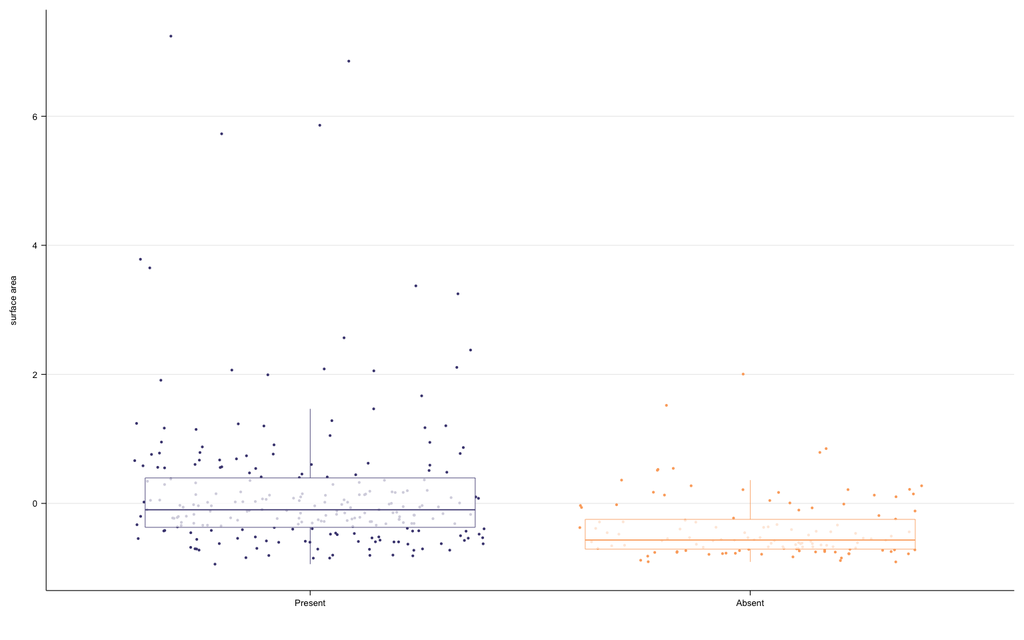

```r
ggplot(glasserparcel.anatomy, aes(x = reconstructed, y = surface_area_z)) +
  geom_point(aes(color = reconstructed, fill = reconstructed), position = position_jitter(width = .4), size = 0.07) +
  geom_boxplot(aes(color = reconstructed), fill = alpha("white", 0.75), size = 0.15, outlier.shape = NA) +
  theme_minimal() +
  scale_color_manual(values = c("#48457F", "#FCAB6A")) +
  labs(x="\n", y="surface area\n") +
  theme(legend.position = "none") +
  theme(
  panel.grid.major = element_line(linewidth = 0.2),
  panel.grid.minor = element_blank(),
  panel.grid.major.x = element_blank(),
  axis.text = element_text(size = 5, family = "Arial", color = c("black")),
  axis.title.x = element_text(size = 5, family ="Arial", color = c("black")),
  axis.title.y = element_text(size = 5, family ="Arial", color = c("black")),
  axis.line = element_line(linewidth = .2),
  axis.ticks = element_line(linewidth = .2))
```

```r
ggsave(filename = "/cbica/projects/thalamocortical_development/figures/images/Figure1/Atlasconnections_surfacearea.pdf", device = "pdf", dpi = 500, width = 1.3 , height = 1.2)
```

```r
var.test(glasserparcel.anatomy$surface_area ~ glasserparcel.anatomy$reconstructed) #variances are not equal
```

```
##
##  F test to compare two variances
##
## data:  glasserparcel.anatomy$surface_area by glasserparcel.anatomy$reconstructed
## F = 5.6802, num df = 237, denom df = 121, p-value < 2.2e-16
## alternative hypothesis: true ratio of variances is not equal to 1
## 95 percent confidence interval:
##  4.129615 7.690281
## sample estimates:
## ratio of variances
##           5.680249
```

```r
t.test(glasserparcel.anatomy$surface_area ~ glasserparcel.anatomy$reconstructed, alternative = "two.sided", var.equal = FALSE)
```

```
##
##  Welch Two Sample t-test
##
## data:  glasserparcel.anatomy$surface_area by glasserparcel.anatomy$reconstructed
## t = 7.0226, df = 347.47, p-value = 1.152e-11
## alternative hypothesis: true difference in means between group Present and group Absent is not equal to 0
## 95 percent confidence interval:
##  146.0647 259.7095
## sample estimates:
## mean in group Present  mean in group Absent
##              493.2912              290.4041
```

## Sulcal depth of parcels with versus without reconstructed thalamocortical connections

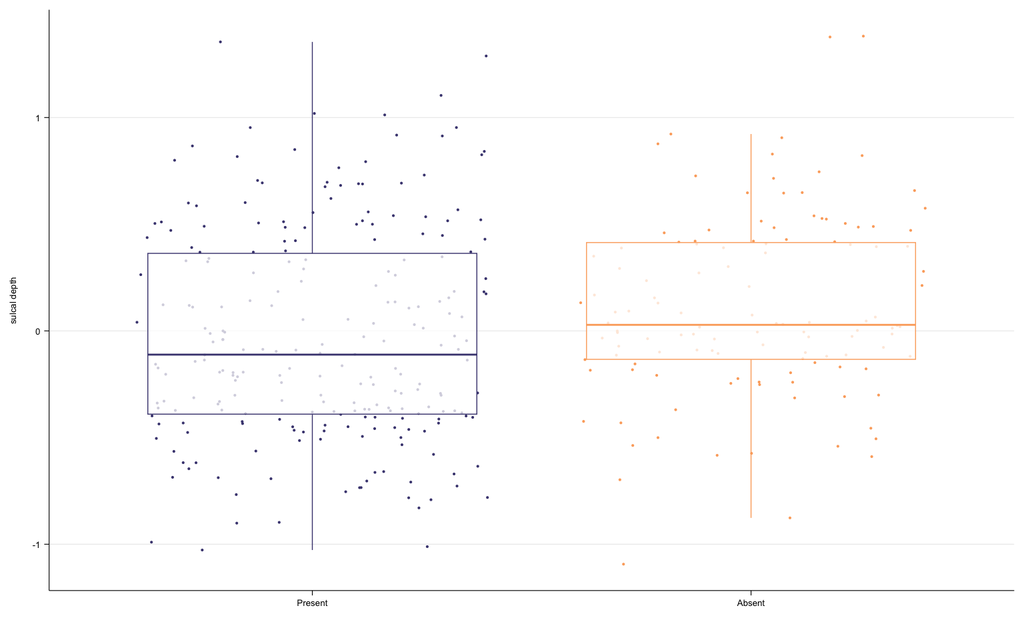

```r
ggplot(glasserparcel.anatomy, aes(x = reconstructed, y = sulcal_depth)) +
  geom_point(aes(color = reconstructed, fill = reconstructed), position = position_jitter(width = .4), size = 0.07) +
  geom_boxplot(aes(color = reconstructed), fill = alpha("white", 0.75), size = 0.25, outlier.shape = NA) +
  theme_minimal() +
  scale_color_manual(values = c("#48457F", "#FCAB6A")) +
  labs(x="\n", y="sulcal depth\n") +
  theme(legend.position = "none") +
  theme(
  panel.grid.major = element_line(linewidth = 0.2),
  panel.grid.minor = element_blank(),
  panel.grid.major.x = element_blank(),
  axis.text = element_text(size = 5, family = "Arial", color = c("black")),
  axis.title.x = element_text(size = 5, family ="Arial", color = c("black")),
  axis.title.y = element_text(size = 5, family ="Arial", color = c("black")),
  axis.line = element_line(linewidth = .2),
  axis.ticks = element_line(linewidth = .2)) +
  scale_y_continuous(breaks = c(-1, 0, 1))
```

```r
ggsave(filename = "/cbica/projects/thalamocortical_development/figures/images/Figure1/Atlasconnections_sulcaldepth.pdf", device = "pdf", dpi = 500, width = 1.3 , height = 1.2)
```

```r
var.test(glasserparcel.anatomy$sulcal_depth ~ glasserparcel.anatomy$reconstructed) #variances are approx equal
```

```
##
##  F test to compare two variances
##
## data:  glasserparcel.anatomy$sulcal_depth by glasserparcel.anatomy$reconstructed
## F = 1.3551, num df = 237, denom df = 121, p-value = 0.06163
## alternative hypothesis: true ratio of variances is not equal to 1
## 95 percent confidence interval:
##  0.9851494 1.8345721
## sample estimates:
## ratio of variances
##           1.355065
```

```r
t.test(glasserparcel.anatomy$sulcal_depth ~ glasserparcel.anatomy$reconstructed, alternative = "two.sided", var.equal = TRUE)
```

```
##
##  Two Sample t-test
##
## data:  glasserparcel.anatomy$sulcal_depth by glasserparcel.anatomy$reconstructed
## t = -2.6362, df = 358, p-value = 0.00875
## alternative hypothesis: true difference in means between group Present and group Absent is not equal to 0
## 95 percent confidence interval:
##  -0.24076222 -0.03502327
## sample estimates:
## mean in group Present  mean in group Absent
##           -0.02950504            0.10838770
```

# Thalamocortical Connectivity Cortical and Thalamic Gradients

S-A axis ranks

```r
S.A.axis.cifti <- read_cifti("/cbica/projects/thalamocortical_development/Maps/S-A_ArchetypalAxis/FSLRVertex/SensorimotorAssociation_Axis_parcellated/SensorimotorAssociation.Axis.Glasser360.pscalar.nii") #S-A_ArchetypalAxis repo
S.A.axis <- data.frame(SA.axis = rank(S.A.axis.cifti$data), orig_parcelname = names(S.A.axis.cifti$Parcel))
S.A.axis <- merge(S.A.axis, glasser.assignments, by="orig_parcelname", sort = F)
```

Sample-specific final tract lists

```r
#Tract lists generated by /tract_measures/tractlists/thalamocortical_tractlists.R
tractlist.hcpd <- read.csv("/cbica/projects/thalamocortical_development/thalamocortical_structuralconnectivity/individual/HCPD/HCPD_tractlist_primary.csv")
tractlist.pnc <- read.csv("/cbica/projects/thalamocortical_development/thalamocortical_structuralconnectivity/individual/PNC/PNC_tractlist_primary.csv")
```

Spatial permutations of the glasser parcellation for spin testing

```r
perm.id.full <- readRDS("/cbica/projects/thalamocortical_development/software/rotate_parcellation/glasser_sphericalrotations_N10000.rds") #10,000 spatial null spins for spin testing (spherical permutation based p-values). Parcel order is right hemisphere -> left hemisphere
spin.parcels <- glasser.regions #order of complete set of glasser parcels for spinning
```

Function to calculate tract-level means per dataset

```r
tract_average_measures <- function(measure, atlas, dataset){
  input.df <- get(sprintf("%s.%s.%s", measure, atlas, dataset)) %>% select(contains("autotrack")) #nrow subjects by ncol tracts for mean calculation
  tract.means <- colMeans(input.df, na.rm = TRUE) %>% as.data.frame %>% set_names(sprintf("mean_%s", measure)) %>% mutate(tract = row.names(.))
  tract.means <- merge(tract.means, S.A.axis, by = "tract")
  return(tract.means)
}
```

## Thalamocortical Connection Fractional Anisotropy

```r
FA.glasser.pnc <- read.csv("/cbica/projects/thalamocortical_development/thalamocortical_structuralconnectivity/individual/PNC/PNC_FA_finalsample_primary.csv") #FA for included tracts and participants

FA.glasser.hcpd <- read.csv("/cbica/projects/thalamocortical_development/thalamocortical_structuralconnectivity/individual/HCPD/HCPD_FA_finalsample_primary.csv")
```

**Calculate mean FA for each tract in PNC and HCPD datasets**

```r
tract.meanFA.pnc <- tract_average_measures(measure = "FA", atlas = "glasser", dataset = "pnc")
tract.meanFA.pnc <- tract.meanFA.pnc[tract.meanFA.pnc$tract %in% tractlist.pnc$tract,] #connection-level mean FA for final PNC tract list
write.csv(tract.meanFA.pnc, "/cbica/projects/thalamocortical_development/thalamocortical_structuralconnectivity/individual/PNC/PNC_tractaverage_FA_primary.csv", row.names = F, quote = F)

tract.meanFA.hcpd <- tract_average_measures(measure = "FA", atlas = "glasser", dataset = "hcpd")
tract.meanFA.hcpd <- tract.meanFA.hcpd[tract.meanFA.hcpd$tract %in% tractlist.hcpd$tract,] #connection-level mean FA for final HCPD tract list
write.csv(tract.meanFA.hcpd, "/cbica/projects/thalamocortical_development/thalamocortical_structuralconnectivity/individual/HCPD/HCPD_tractaverage_FA_primary.csv", row.names = F, quote = F)
```

**Correlation of connection-level average FA between datasets**

```r
tract.meanFA.merged <- merge((tract.meanFA.pnc %>% select(tract, mean_FA)), (tract.meanFA.hcpd %>% select(tract, mean_FA)), by = "tract") %>% set_names("tract", "mean_FA.pnc", "mean_FA.hcpd")

cor.test(tract.meanFA.merged$mean_FA.pnc, tract.meanFA.merged$mean_FA.hcpd)
```

```
##
##  Pearson's product-moment correlation
##
## data:  tract.meanFA.merged$mean_FA.pnc and tract.meanFA.merged$mean_FA.hcpd
## t = 61.035, df = 219, p-value < 2.2e-16
## alternative hypothesis: true correlation is not equal to 0
## 95 percent confidence interval:
##  0.9634361 0.9783363
## sample estimates:
##       cor
## 0.9718417
```

*Spatial permutation (spin) based p-value*

```r
spin.data <- left_join(spin.parcels, tract.meanFA.merged, by = "tract") #full set of parcel data in rh --> lh order for spinning. spin test null correlations use complete obs only. Each null correlation correspondence statistic is thus computed on a slightly  reduced set of data, akin to a jackknife procedure
perm.sphere.p(x = spin.data$mean_FA.pnc, y = spin.data$mean_FA.hcpd, perm.id = perm.id.full, corr.type = "pearson")
```

```
## [1] 0
```

*Correlation plot*

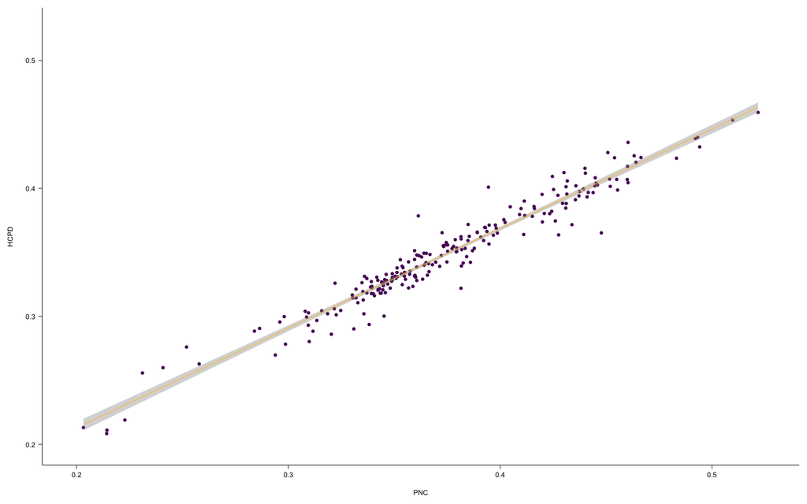

```r
ggplot(tract.meanFA.merged, aes(x = mean_FA.pnc, y = mean_FA.hcpd)) +
  geom_point(color = c("#571766"), size = 0.5) +
  geom_smooth(method = "lm", color = c("goldenrod1"), formula = y ~ x, linewidth = 0.2) +
  theme_classic() +
  scale_x_continuous(limits = c(0.2, 0.525)) +
  scale_y_continuous(limits = c(0.2, 0.525)) +
  labs(x="\nPNC", y="HCPD\n") +
  theme(
  axis.text = element_text(size = 5, family = "Arial", color = c("black")),
  axis.title.x = element_text(size = 5, family ="Arial", color = c("black")),
  axis.title.y = element_text(size = 5, family ="Arial", color = c("black")),
  axis.line = element_line(linewidth = .2),
  axis.ticks = element_line(linewidth = .2))
```

```r
ggsave(filename = "/cbica/projects/thalamocortical_development/figures/images/Figure3/FA_correlation_PNCHCPD.pdf", device = "pdf", dpi = 500, width = 1.45, height = 1.3)
```

**Thalamocortical connectivity FA differs by Mesulam cortical type**

*Welch’s ANOVA with unequal variances to test for significant differences between cortical types, with Games Howell post-hoc tests*

PNC

```r
tract.meanFA.pnc$mesulam_assignment <- factor(tract.meanFA.pnc$mesulam_assignment, levels = c("idiotypic", "unimodal", "heteromodal", "paralimbic")) #order from idiotypic --> paralimbic

leveneTest(tract.meanFA.pnc$mean_FA ~ tract.meanFA.pnc$mesulam_assignment) #variances are not equal
```

```
## Levene's Test for Homogeneity of Variance (center = median)
##        Df F value    Pr(>F)
## group   3  7.4024 9.568e-05 ***
##       219
## ---
## Signif. codes:  0 '***' 0.001 '**' 0.01 '*' 0.05 '.' 0.1 ' ' 1
```

```r
oneway.test(tract.meanFA.pnc$mean_FA ~ tract.meanFA.pnc$mesulam_assignment, var.equal = FALSE) #one-way analysis of means for unequal variances
```

```
##
##  One-way analysis of means (not assuming equal variances)
##
## data:  tract.meanFA.pnc$mean_FA and tract.meanFA.pnc$mesulam_assignment
## F = 16.133, num df = 3.000, denom df = 69.064, p-value = 4.757e-08
```

```r
tract.meanFA.pnc %>% games_howell_test(mean_FA ~ mesulam_assignment) #performs Games-Howell test, which is used to compare all possible combinations of group differences when the assumption of homogeneity of variances is violated
```

```
## # A tibble: 6 × 8
##   .y.     group1      group2    estimate conf.low conf.high   p.adj p.adj.signif
## * <chr>   <chr>       <chr>        <dbl>    <dbl>     <dbl>   <dbl> <chr>
## 1 mean_FA idiotypic   unimodal  -0.0211   -0.0533  0.0112   3.18e-1 ns
## 2 mean_FA idiotypic   heteromo… -0.0304   -0.0614  0.000484 5.5 e-2 ns
## 3 mean_FA idiotypic   paralimb… -0.0975   -0.138  -0.0568   2.70e-7 ****
## 4 mean_FA unimodal    heteromo… -0.00938  -0.0268  0.00808  5.03e-1 ns
## 5 mean_FA unimodal    paralimb… -0.0764   -0.109  -0.0437   2.37e-6 ****
## 6 mean_FA heteromodal paralimb… -0.0671   -0.0986 -0.0355   1.92e-5 ****
```

HCPD

```r
tract.meanFA.hcpd$mesulam_assignment <- factor(tract.meanFA.hcpd$mesulam_assignment, levels = c("idiotypic", "unimodal", "heteromodal", "paralimbic"))

leveneTest(tract.meanFA.hcpd$mean_FA ~ tract.meanFA.hcpd$mesulam_assignment) #variances are not equal
```

```
## Levene's Test for Homogeneity of Variance (center = median)
##        Df F value    Pr(>F)
## group   3  9.0727 1.073e-05 ***
##       226
## ---
## Signif. codes:  0 '***' 0.001 '**' 0.01 '*' 0.05 '.' 0.1 ' ' 1
```

```r
oneway.test(tract.meanFA.hcpd$mean_FA ~ tract.meanFA.hcpd$mesulam_assignment, var.equal = FALSE) #one-way analysis of means for unequal variances
```

```
##
##  One-way analysis of means (not assuming equal variances)
##
## data:  tract.meanFA.hcpd$mean_FA and tract.meanFA.hcpd$mesulam_assignment
## F = 13.164, num df = 3.000, denom df = 69.184, p-value = 6.803e-07
```

```r
tract.meanFA.hcpd %>% games_howell_test(mean_FA ~ mesulam_assignment)
```

```
## # A tibble: 6 × 8
##   .y.     group1      group2    estimate conf.low conf.high   p.adj p.adj.signif
## * <chr>   <chr>       <chr>        <dbl>    <dbl>     <dbl>   <dbl> <chr>
## 1 mean_FA idiotypic   unimodal  -0.0162   -0.0415   0.00902 3.34e-1 ns
## 2 mean_FA idiotypic   heteromo… -0.0224   -0.0466   0.00177 7.8 e-2 ns
## 3 mean_FA idiotypic   paralimb… -0.0754   -0.109   -0.0416  1.64e-6 ****
## 4 mean_FA unimodal    heteromo… -0.00618  -0.0202   0.00781 6.6 e-1 ns
## 5 mean_FA unimodal    paralimb… -0.0592   -0.0875  -0.0309  1.88e-5 ****
## 6 mean_FA heteromodal paralimb… -0.0530   -0.0805  -0.0256  8.55e-5 ****
```

*Mesulam cortical type plot*

```r
mesulam.means <-  tract.meanFA.pnc %>% group_by(mesulam_assignment) %>% summarise(mean = mean(mean_FA)) #calculate mean FA in each type for plotting
mesulam.means
```

```
## # A tibble: 4 × 2
##   mesulam_assignment  mean
##   <fct>              <dbl>
## 1 idiotypic          0.403
## 2 unimodal           0.382
## 3 heteromodal        0.373
## 4 paralimbic         0.305
```

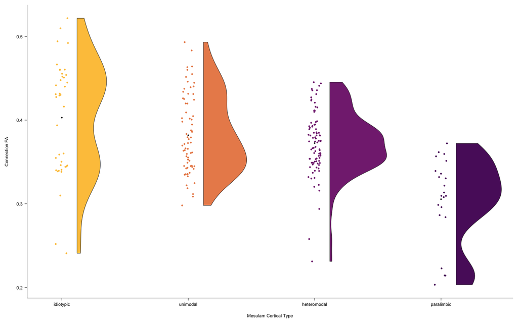

```r
ggplot(tract.meanFA.pnc, aes(x = mesulam_assignment, y = mean_FA)) +
  geom_point(aes(color = mesulam_assignment, fill = mesulam_assignment), size = 0.25, position = position_jitter(width = .05)) +
  geom_flat_violin(aes(fill = mesulam_assignment), position = position_nudge(x = .12, y = 0), alpha = .99, size = 0.2) +
  geom_point(data = mesulam.means, aes(x = mesulam_assignment, y = mean), shape = 21 , color = "white", stroke = .3,  fill = "black", size = 0.8) +
  scale_x_discrete(expand = c(0.125, -0.1)) +
  scale_color_manual(values = c("#FDC446", "#EA8B57", "#822A7E", "#581768")) +
  scale_fill_manual(values = c("#FDC446", "#EA8B57", "#822A7E", "#581768")) +
  theme_classic() +
  theme(legend.position = "none") +
  labs(x="\nMesulam Cortical Type", y="Connection FA\n") +
  theme(
  panel.grid.minor = element_blank(),
  panel.grid.major.x = element_blank(),
  axis.text = element_text(size = 5, family = "Arial", color = c("black")),
  axis.title.x = element_text(size = 5, family ="Arial", color = c("black")),
  axis.title.y = element_text(size = 5, family ="Arial", color = c("black")),
  axis.line = element_line(linewidth = .2),
  axis.ticks = element_line(linewidth = .2))
```

```r
ggsave(filename = "/cbica/projects/thalamocortical_development/figures/images/Figure3/FA_mesulamtype_PNC.pdf", device = "pdf", dpi = 500, width = 1.75, height = 1.3)
```

**Thalamocortical connectivity FA organization along the S-A axis**

*Spearman’s correlations*

PNC

```r
cor.test(tract.meanFA.pnc$mean_FA, tract.meanFA.pnc$SA.axis, method = c("spearman"))
```

```
##
##  Spearman's rank correlation rho
##
## data:  tract.meanFA.pnc$mean_FA and tract.meanFA.pnc$SA.axis
## S = 2633482, p-value = 4.941e-11
## alternative hypothesis: true rho is not equal to 0
## sample estimates:
##        rho
## -0.4248717
```

HCPD

```r
cor.test(tract.meanFA.hcpd$mean_FA, tract.meanFA.hcpd$SA.axis, method = c("spearman"))
```

```
##
##  Spearman's rank correlation rho
##
## data:  tract.meanFA.hcpd$mean_FA and tract.meanFA.hcpd$SA.axis
## S = 2877106, p-value = 4.988e-11
## alternative hypothesis: true rho is not equal to 0
## sample estimates:
##        rho
## -0.4188347
```

*Spatial permutation (spin) based p-value*

PNC

```r
spin.data <- left_join(spin.parcels, tract.meanFA.pnc, by = c("orig_parcelname", "label", "tract"))
perm.sphere.p(x = spin.data$mean_FA, y = spin.data$SA.axis, perm.id = perm.id.full, corr.type = "pearson")
```

```
## [1] 0.02495
```

HCPD

```r
spin.data <- left_join(spin.parcels, tract.meanFA.hcpd, by = c("orig_parcelname", "label", "tract"))
perm.sphere.p(x = spin.data$mean_FA, y = spin.data$SA.axis, perm.id = perm.id.full, corr.type = "pearson")
```

```
## [1] 0.0341
```

*Thalamocortical FA by S-A axis plot*

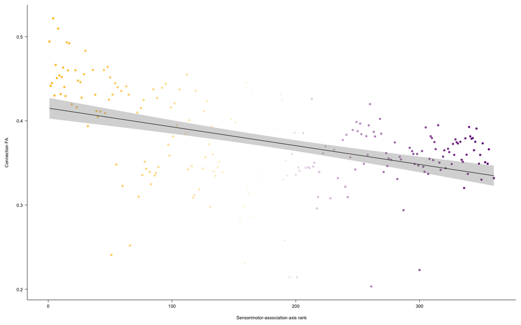

```r
ggplot(tract.meanFA.pnc, aes(x = SA.axis, y = mean_FA)) +
  geom_point(aes(color = SA.axis), size = 0.5) +
  geom_smooth(method = "lm", linewidth = 0.3, color = c("gray25")) +
  theme_classic() +
  scale_fill_gradient2(low = "goldenrod1", mid = "white", high = "#6f1282", guide = "colourbar", aesthetics = "color", name = NULL, limits = c(1, 360), midpoint = 180) +
  labs(x="\nSensorimotor-association axis rank", y="Connection FA\n") +
  theme(legend.position = "none") +
  theme(
  panel.grid.minor = element_blank(),
  panel.grid.major.x = element_blank(),
  axis.text = element_text(size = 5, family = "Arial", color = c("black")),
  axis.title.x = element_text(size = 5, family ="Arial", color = c("black")),
  axis.title.y = element_text(size = 5, family ="Arial", color = c("black")),
  axis.line = element_line(linewidth = .2),
  axis.ticks = element_line(linewidth = .2))
```

```r
ggsave(filename = "/cbica/projects/thalamocortical_development/figures/images/Figure3/FA_SArank_PNC.pdf", device = "pdf", dpi = 500, width = 1.7, height = 1.3)
```

## Thalamocortical Connection Core-Matrix Gradient (CPt) Values

Read in connection-specific core-matrix gradient values (based on the connection’s thalamic endpoints and the thalamic calbindin-parvalbumin CPt gradient) and get data for just final study sample and included tracts

```r
extract_measure <- function(metric.df, participants.df, measure){
  measure.df <- metric.df %>% select(rbcid, tract, all_of(measure)) #extract measure of interest from long df
  measure.df <- measure.df %>% arrange(tract) #tracts in alphabetical order
  measure.df <- measure.df %>% pivot_wider(names_from = "tract", values_from = all_of(measure)) #long to wide format, all participants and tracts
  measure.df <- measure.df %>% arrange(rbcid)  #rbcids in numerical order
  colnames(measure.df) <- gsub("-", "_", colnames(measure.df))
  measure.df <- measure.df[measure.df$rbcid %in% participants.df$rbcid,] #only final sample of participants now
  return(measure.df)
}
```

PNC

```r
#Create connection CPt value spreadsheet for final sample of PNC participants
CPt.glasser.pnc.long <- read.csv("/cbica/projects/thalamocortical_development/thalamocortical_structuralconnectivity/individual/PNC/PNC_thalamicconnection_CPt.csv") #thalamic connection CPt gradient values, generated by /tract_measures/CPtgradient_values/lthalamocortical_calculate_CPtvalues.sh and /tract_measures/CPtgradient_values/thalamocortical_CPtvalues.py
participants.pnc <- read.csv("/cbica/projects/thalamocortical_development/sample_info/PNC/PNC_thalamocortical_finalsample_N1145.csv") #PNC final participant list
CPt.glasser.pnc <- extract_measure(metric.df = CPt.glasser.pnc.long, participants.df = participants.pnc, measure = "CPt")

#Don't analyze CPt values for connections with <5 streamlines
streamlinecount.glasser.pnc <- read.csv("/cbica/projects/thalamocortical_development/thalamocortical_structuralconnectivity/individual/PNC/PNC_streamlinecount_finalsample.csv")
#identical(streamlinecount.glasser.pnc$rbcid, CPt.glasser.pnc$rbcid) = TRUE; internal check
streamlinecount.glasser.pnc <- streamlinecount.glasser.pnc %>% select(contains("autotrack")) #1145 subjects by 238 tracts
CPt.glasser.pnc <- CPt.glasser.pnc %>% select(contains("autotrack")) #1145 subjects by 238 tracts
#identical(names(streamlinecount.glasser.pnc), names(CPt.glasser.pnc)) = TRUE; internal check
CPt.glasser.pnc <- CPt.glasser.pnc * ifelse(streamlinecount.glasser.pnc >= 5, 1, NA)
```

HCPD

```r
#Create connection CPt value spreadsheet for final sample of HCPD participants
CPt.glasser.hcpd.long <- read.csv("/cbica/projects/thalamocortical_development/thalamocortical_structuralconnectivity/individual/HCPD/HCPD_thalamicconnection_CPt.csv")
participants.hcpd <- read.csv("/cbica/projects/thalamocortical_development/sample_info/HCPD/HCPD_thalamocortical_finalsample_N572.csv") #HCPD final participant list
CPt.glasser.hcpd <- extract_measure(metric.df = CPt.glasser.hcpd.long, participants.df = participants.hcpd, measure = "CPt")

#Don't analyze CPt values for connections with <5 streamlines
streamlinecount.glasser.hcpd <- read.csv("/cbica/projects/thalamocortical_development/thalamocortical_structuralconnectivity/individual/HCPD/HCPD_streamlinecount_finalsample.csv")
#identical(streamlinecount.glasser.hcpd$rbcid, CPt.glasser.hcpd$rbcid) = TRUE; internal check
streamlinecount.glasser.hcpd <- streamlinecount.glasser.hcpd %>% select(contains("autotrack")) #572 subjects by 238 tracts
CPt.glasser.hcpd <- CPt.glasser.hcpd %>% select(contains("autotrack")) #572 subjects by 238 tracts
#identical(names(streamlinecount.glasser.hcpd), names(CPt.glasser.hcpd)) = TRUE; internal check
CPt.glasser.hcpd <- CPt.glasser.hcpd * ifelse(streamlinecount.glasser.hcpd >= 5, 1, NA)
```

**Calculate thalamic connection area CPt value for each tract in PNC and HCPD datasets**

```r
tract.meanCPt.pnc <- tract_average_measures(measure = "CPt", atlas = "glasser", dataset = "pnc")
tract.meanCPt.pnc <- tract.meanCPt.pnc[tract.meanCPt.pnc$tract %in% tractlist.pnc$tract,]
write.csv(tract.meanCPt.pnc, "/cbica/projects/thalamocortical_development/thalamocortical_structuralconnectivity/individual/PNC/PNC_tractaverage_CPt_primary.csv", row.names = F, quote = F)

tract.meanCPt.hcpd <- tract_average_measures(measure = "CPt", atlas = "glasser", dataset = "hcpd")
tract.meanCPt.hcpd <- tract.meanCPt.hcpd[tract.meanCPt.hcpd$tract %in% tractlist.hcpd$tract,]
write.csv(tract.meanCPt.hcpd, "/cbica/projects/thalamocortical_development/thalamocortical_structuralconnectivity/individual/HCPD/HCPD_tractaverage_CPt_primary.csv", row.names = F, quote = F)
```

**Correlation of connection-level average CPt between datasets**

```r
tract.meanCPt.merged <- merge((tract.meanCPt.pnc %>% select(tract, mean_CPt)), (tract.meanCPt.hcpd %>% select(tract, mean_CPt)), by = "tract") %>% set_names("tract", "mean_CPt.pnc", "mean_CPt.hcpd")

cor.test(tract.meanCPt.merged$mean_CPt.pnc, tract.meanCPt.merged$mean_CPt.hcpd)
```

```
##
##  Pearson's product-moment correlation
##
## data:  tract.meanCPt.merged$mean_CPt.pnc and tract.meanCPt.merged$mean_CPt.hcpd
## t = 93.485, df = 219, p-value < 2.2e-16
## alternative hypothesis: true correlation is not equal to 0
## 95 percent confidence interval:
##  0.9839914 0.9905554
## sample estimates:
##       cor
## 0.9877012
```

*Spatial permutation (spin) based p-value*

```r
spin.data <- left_join(spin.parcels, tract.meanCPt.merged, by = "tract")
perm.sphere.p(x = spin.data$mean_CPt.pnc, y = spin.data$mean_CPt.hcpd, perm.id = perm.id.full, corr.type = "pearson")
```

```
## [1] 0
```

*Correlation plot*

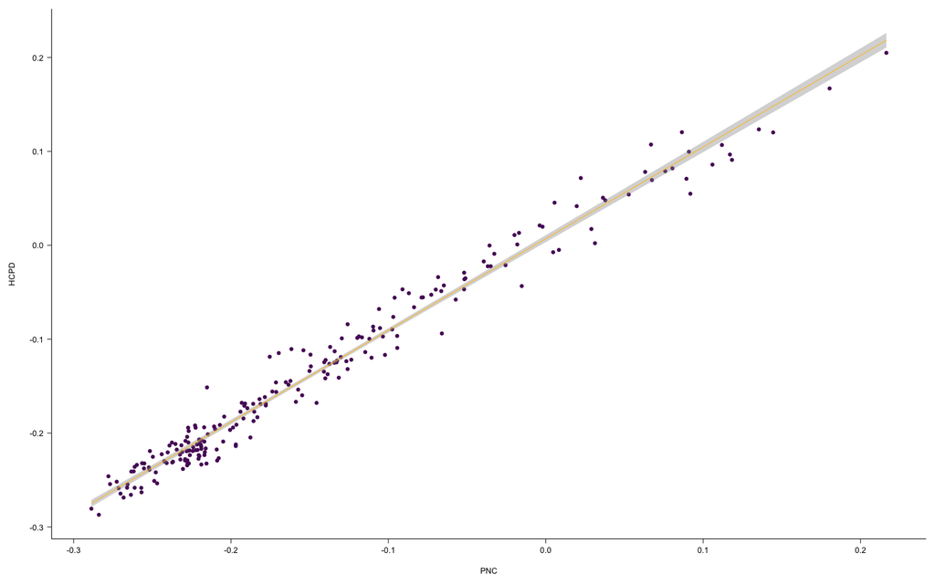

```r
ggplot(tract.meanCPt.merged, aes(x = mean_CPt.pnc, y = mean_CPt.hcpd)) +
  geom_point(color = c("#571766"), size = 0.5) +
  geom_smooth(method = "lm", color = c("goldenrod1"), formula = y ~ x, linewidth = 0.2) +
  theme_classic() +
  labs(x="\nPNC", y="HCPD\n") +
  theme(
  axis.text = element_text(size = 5, family = "Arial", color = c("black")),
  axis.title.x = element_text(size = 5, family ="Arial", color = c("black")),
  axis.title.y = element_text(size = 5, family ="Arial", color = c("black")),
  axis.line = element_line(linewidth = .2),
  axis.ticks = element_line(linewidth = .2))
```

```r
ggsave(filename = "/cbica/projects/thalamocortical_development/figures/images/Figure3/CPt_correlation_PNCHCPD.pdf", device = "pdf", dpi = 500, width = 1.5, height = 1.3)
```

**Thalamocortical connectivity CPt differs by Mesulam cortical type**

*Welch’s ANOVA with unequal variances to test for significant differences between cortical types, with Games Howell post-hoc tests*

PNC

```r
tract.meanCPt.pnc$mesulam_assignment <- factor(tract.meanCPt.pnc$mesulam_assignment, levels = c("idiotypic", "unimodal", "heteromodal", "paralimbic"))

leveneTest(tract.meanCPt.pnc$mean_CPt ~ tract.meanCPt.pnc$mesulam_assignment) #variances are not equal
```

```
## Levene's Test for Homogeneity of Variance (center = median)
##        Df F value    Pr(>F)
## group   3  10.317 2.223e-06 ***
##       219
## ---
## Signif. codes:  0 '***' 0.001 '**' 0.01 '*' 0.05 '.' 0.1 ' ' 1
```

```r
oneway.test(tract.meanCPt.pnc$mean_CPt ~ tract.meanCPt.pnc$mesulam_assignment, var.equal = FALSE) #one-way analysis of means for unequal variances
```

```
##
##  One-way analysis of means (not assuming equal variances)
##
## data:  tract.meanCPt.pnc$mean_CPt and tract.meanCPt.pnc$mesulam_assignment
## F = 9.2943, num df = 3.000, denom df = 80.521, p-value = 2.396e-05
```

```r
tract.meanCPt.pnc %>% games_howell_test(mean_CPt ~ mesulam_assignment)
```

```
## # A tibble: 6 × 8
##   .y.      group1      group2   estimate conf.low conf.high   p.adj p.adj.signif
## * <chr>    <chr>       <chr>       <dbl>    <dbl>     <dbl>   <dbl> <chr>
## 1 mean_CPt idiotypic   unimodal  0.0159   -0.0233   0.0551  7.13e-1 ns
## 2 mean_CPt idiotypic   heterom…  0.0900    0.0437   0.136   9.05e-6 ****
## 3 mean_CPt idiotypic   paralim…  0.0248   -0.0296   0.0791  6.17e-1 ns
## 4 mean_CPt unimodal    heterom…  0.0741    0.0307   0.117   1.01e-4 ***
## 5 mean_CPt unimodal    paralim…  0.00886  -0.0432   0.0609  9.68e-1 ns
## 6 mean_CPt heteromodal paralim… -0.0652   -0.122   -0.00799 2   e-2 *
```

HCPD

```r
tract.meanCPt.hcpd$mesulam_assignment <- factor(tract.meanCPt.hcpd$mesulam_assignment, levels = c("idiotypic", "unimodal", "heteromodal", "paralimbic"))

leveneTest(tract.meanCPt.hcpd$mean_CPt ~ tract.meanCPt.hcpd$mesulam_assignment) #variances are not equal
```

```
## Levene's Test for Homogeneity of Variance (center = median)
##        Df F value    Pr(>F)
## group   3  9.1893 9.226e-06 ***
##       226
## ---
## Signif. codes:  0 '***' 0.001 '**' 0.01 '*' 0.05 '.' 0.1 ' ' 1
```

```r
oneway.test(tract.meanCPt.hcpd$mean_CPt ~ tract.meanCPt.hcpd$mesulam_assignment, var.equal = FALSE) #one-way analysis of means for unequal variances
```

```
##
##  One-way analysis of means (not assuming equal variances)
##
## data:  tract.meanCPt.hcpd$mean_CPt and tract.meanCPt.hcpd$mesulam_assignment
## F = 8.2547, num df = 3.000, denom df = 79.323, p-value = 7.588e-05
```

```r
tract.meanCPt.hcpd %>% games_howell_test(mean_CPt ~ mesulam_assignment)
```

```
## # A tibble: 6 × 8
##   .y.      group1      group2   estimate conf.low conf.high   p.adj p.adj.signif
## * <chr>    <chr>       <chr>       <dbl>    <dbl>     <dbl>   <dbl> <chr>
## 1 mean_CPt idiotypic   unimodal   0.0154  -0.0260   0.0568  7.65e-1 ns
## 2 mean_CPt idiotypic   heterom…   0.0839   0.0374   0.130   4.18e-5 ****
## 3 mean_CPt idiotypic   paralim…   0.0272  -0.0340   0.0883  6.35e-1 ns
## 4 mean_CPt unimodal    heterom…   0.0685   0.0256   0.111   3.15e-4 ***
## 5 mean_CPt unimodal    paralim…   0.0118  -0.0470   0.0706  9.48e-1 ns
## 6 mean_CPt heteromodal paralim…  -0.0567  -0.119    0.00548 8.5 e-2 ns
```

*Mesulam cortical type plot*

```r
mesulam.means <-  tract.meanCPt.pnc %>% group_by(mesulam_assignment) %>% summarise(mean = mean(mean_CPt)) #calculate mean CPt in each type for plotting
mesulam.means
```

```
## # A tibble: 4 × 2
##   mesulam_assignment    mean
##   <fct>                <dbl>
## 1 idiotypic          -0.190
## 2 unimodal           -0.174
## 3 heteromodal        -0.0999
## 4 paralimbic         -0.165
```

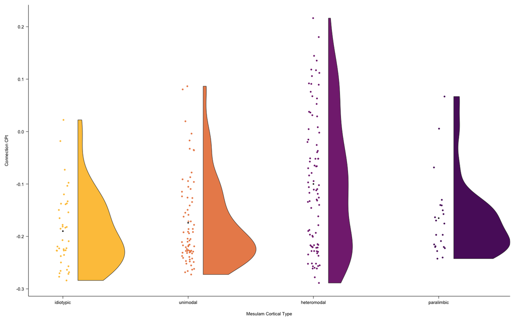

```r
ggplot(tract.meanCPt.pnc, aes(x = mesulam_assignment, y = mean_CPt)) +
  geom_point(aes(color = mesulam_assignment, fill = mesulam_assignment), size = 0.25, position = position_jitter(width = .05)) +
  geom_flat_violin(aes(fill = mesulam_assignment), position = position_nudge(x = .12, y = 0), alpha = .99, size = 0.2) +
  geom_point(data = mesulam.means, aes(x = mesulam_assignment, y = mean), shape = 21 , color = "white", stroke = .3,  fill = "black", size = 0.8) +
  scale_x_discrete(expand = c(0.125, -0.1)) +
  scale_color_manual(values = c("#FDC446", "#EA8B57", "#822A7E", "#581768")) +
  scale_fill_manual(values = c("#FDC446", "#EA8B57", "#822A7E", "#581768")) +
  theme_classic() +
  theme(legend.position = "none") +
  labs(x="\nMesulam Cortical Type", y="Connection CPt\n") +
  theme(
  panel.grid.minor = element_blank(),
  panel.grid.major.x = element_blank(),
  axis.text = element_text(size = 5, family = "Arial", color = c("black")),
  axis.title.x = element_text(size = 5, family ="Arial", color = c("black")),
  axis.title.y = element_text(size = 5, family ="Arial", color = c("black")),
  axis.line = element_line(linewidth = .2),
  axis.ticks = element_line(linewidth = .2))
```

```r
ggsave(filename = "/cbica/projects/thalamocortical_development/figures/images/Figure3/CPt_mesulamtype_PNC.pdf", device = "pdf", dpi = 500, width = 1.85, height = 1.3)
```

**Thalamocortical connectivity CPt organization along the S-A axis**

*Spearman’s correlations*

PNC

```r
cor.test(tract.meanCPt.pnc$mean_CPt, tract.meanCPt.pnc$SA.axis, method = c("spearman"))
```

```
##
##  Spearman's rank correlation rho
##
## data:  tract.meanCPt.pnc$mean_CPt and tract.meanCPt.pnc$SA.axis
## S = 781550, p-value < 2.2e-16
## alternative hypothesis: true rho is not equal to 0
## sample estimates:
##       rho
## 0.5771346
```

HCPD

```r
cor.test(tract.meanCPt.hcpd$mean_CPt, tract.meanCPt.hcpd$SA.axis, method = c("spearman"))
```

```
##
##  Spearman's rank correlation rho
##
## data:  tract.meanCPt.hcpd$mean_CPt and tract.meanCPt.hcpd$SA.axis
## S = 1015854, p-value < 2.2e-16
## alternative hypothesis: true rho is not equal to 0
## sample estimates:
##       rho
## 0.4990352
```

*Spatial permutation (spin) based p-value*

PNC

```r
spin.data <- left_join(spin.parcels, tract.meanCPt.pnc, by = c("orig_parcelname", "label", "tract"))
perm.sphere.p(x = spin.data$mean_CPt, y = spin.data$SA.axis, perm.id = perm.id.full, corr.type = "pearson")
```

```
## [1] 0.0178
```

HCPD

```r
spin.data <- left_join(spin.parcels, tract.meanCPt.hcpd, by = c("orig_parcelname", "label", "tract"))
perm.sphere.p(x = spin.data$mean_CPt, y = spin.data$SA.axis, perm.id = perm.id.full, corr.type = "pearson")
```

```
## [1] 0.0358
```

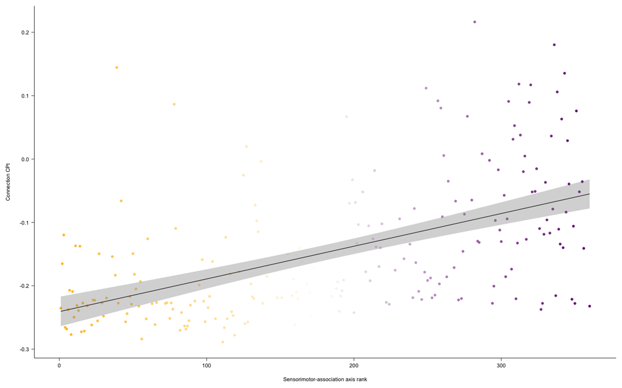

```r
ggplot(tract.meanCPt.pnc, aes(x = SA.axis, y = mean_CPt)) +
  geom_point(aes(color = SA.axis), size = 0.5) +
  geom_smooth(method = "lm", linewidth = 0.3, color = c("gray25")) +
  theme_classic() +
  scale_fill_gradient2(low = "goldenrod1", mid = "white", high = "#6f1282", guide = "colourbar", aesthetics = "color", name = NULL, limits = c(1, 360), midpoint = 180) +
  labs(x="\nSensorimotor-association axis rank", y="Connection CPt\n") +
  theme(legend.position = "none") +
  theme(
  panel.grid.minor = element_blank(),
  panel.grid.major.x = element_blank(),
  axis.text = element_text(size = 5, family = "Arial", color = c("black")),
  axis.title.x = element_text(size = 5, family ="Arial", color = c("black")),
  axis.title.y = element_text(size = 5, family ="Arial", color = c("black")),
  axis.line = element_line(linewidth = .2),
  axis.ticks = element_line(linewidth = .2))
```

```r
ggsave(filename = "/cbica/projects/thalamocortical_development/figures/images/Figure3/CPt_SArank_PNC.pdf", device = "pdf", dpi = 500, width = 1.75, height = 1.3)
```